# Projeto Indicium - Lighthouse: Machine Learning

Candidato: Renato Massamitsu Zama Inomata

## O problema

*Você foi alocado(a) em um time da Indicium que está trabalhando atualmente junto a um cliente que o core business é compra e venda de veículos usados. Essa empresa está com dificuldades na área de revenda dos automóveis usados em seu catálogo.*

*Para resolver esse problema, a empresa comprou uma base de dados de um marketplace de compra e venda para entender melhor o mercado nacional, de forma a conseguir precificar o seu catálogo de forma mais competitiva e assim recuperar o mau desempenho neste setor.*

*Seu objetivo é analisar os dados para responder às perguntas de negócios feitas pelo cliente e criar um modelo preditivo que precifique os carros do cliente de forma que eles fiquem o mais próximos dos valores de mercado.*

Este notebook contém a etapa referente ao ML do projeto.

O conteúdo será dividido em 5 partes:

- I) Introdução, onde importaremos as bibliotecas e dados necessários;
- II) Modelos, onde conduziremos os testes para as predições, tanto no conjunto de dados quanto nos algoritmos de ML;
- III) Seleção do modelo e tuning de hiperparâmetros, onde definiremos o modelo final a ser utilizado e tunamos seus hiperparâmetros;
- IV) Exportação do modelo e dos resultados, onde obteremos os resultados para o conjunto de teste e exportamos para um .csv e o modelo para um .joblib;
- V) Conclusões, onde discorreremos sobre os resultados encontrados e algumas sugestões de trabalhos futuros.

## I) Introdução

Para o desafio apresentado, estaremos resolvendo um problema de regressão, uma vez que nosso objetivo é prever uma variável contínua (neste caso o preço dos veículos).

Estaremos utilizando o pacote `sklearn` para a criação dos modelos, fazendo uso de algoritmos de Regressão Linear e Floresta Aleatória.

### Importando bibliotecas

```python
import pandas as pd
import numpy as np
import matplotlib.pyplot as plt
import seaborn as sns
from sklearn.preprocessing import StandardScaler
from sklearn.model_selection import train_test_split, KFold, cross_validate
from sklearn.pipeline import Pipeline
from sklearn.linear_model import LinearRegression, ElasticNet
from sklearn.ensemble import RandomForestRegressor
from sklearn.metrics import mean_squared_error, r2_score
from sklearn.model_selection import GridSearchCV
from sklearn.feature_extraction.text import CountVectorizer
from joblib import dump, load
import re

pd.set_option('display.max_columns', None)
```

### Importando dados

Transformações realizadas:

- `ano_modelo` e `num_fotos`: alterados para `int`;
- `dono_aceita_troca`, `veiculo_único_dono`, `revisoes_concessionaria`, `ipva_pago`, `veiculo_licenciado`, `garantia_de_fábrica`, `revisoes_dentro_agenda`, `blindado`: alterados para booleanos (1 ou 0);
- `veiculo_alienado` e `elegivel_revisao`: removidos pois todas as observações são iguais;
- `tipo_vendedor`: alterado para `vendedor_PJ` e transformado em booleano.

```python
# Ler dados de treino
df = pd.read_csv('./datasets/cars_train.csv', sep='\t', encoding='utf_16')

# Transformar para inteiro
df['ano_modelo'] = df.ano_modelo.astype(int)
df['num_fotos'] = df.num_fotos.fillna(0).astype(int)

# Transformar em booleanos
df['dono_aceita_troca'] = df.dono_aceita_troca.notnull().astype(int)
df['veiculo_único_dono'] = df.veiculo_único_dono.notnull().astype(int)
df['revisoes_concessionaria'] = df.revisoes_concessionaria.notnull().astype(int)
df['ipva_pago'] = df.ipva_pago.notnull().astype(int)
df['veiculo_licenciado'] = df.veiculo_licenciado.notnull().astype(int)
df['garantia_de_fábrica'] = df.garantia_de_fábrica.notnull().astype(int)
df['revisoes_dentro_agenda'] = df.revisoes_dentro_agenda.notnull().astype(int)
df['entrega_delivery'] = df.entrega_delivery.astype(int)
df['troca'] = df.troca.astype(int)
df['blindado'] = df.blindado.map({'N': 0, 'S': 1})

# Colunas descartadas
df.drop(columns=['veiculo_alienado'], inplace=True)
df.drop(columns=['elegivel_revisao'], inplace=True)

# Remapeando tipo_vendedor e alterando o nome da variável
df['tipo_vendedor'] = df.tipo_vendedor.map({'PJ': 1, 'PF': 0})
df.rename(columns={'tipo_vendedor':'vendedor_PJ'}, inplace=True)
```

## II) Modelos

Para os modelos de Machine Learning, iremos treinar um modelo base e então usar seus resultados como benchmark e compará-los com os demais.

Para modelos lineares estaremos utilizando o `StandardScaler` para escalonar os dados, uma vez que esse tipo de algoritmo de Machine Learning é sensível à dados que não estão em escala.

Para avaliar os testes realizados, faremos uso de um K-Fold com 5 splits, e avaliaremos os scores obtidos pelo modelo.

Quanto as métricas utilizadas, optamos pelo R² e pelo RMSE (raiz do erro quadrático médio). O R² é uma medida de 0 a 1 que expressa a quantidade da variância dos dados, já o RMSE é a raiz da soma dos quadrados dos erros, e tem a vantagem de estar na mesma unidade de medida que o próprio target (neste caso R$).

### Modelo 1 - LinearRegression

O primeiro modelo que testaremos será o de regressão linear. Isso porque esse algoritmo é um dos mais simples e tem uma boa interpretabilidade dos resultados.

Porém, devemos nos atentar com as variáveis categóricas. A princípio, vamos transformar as features `tipo`, `cambio`, `cor` e `anunciante` em dummies, removendo o primeiro valor de cada (drop_first), a fim de evitar problemas de colinearidade.

```python
df1 = pd.get_dummies(df, columns=['tipo', 'cambio', 'cor', 'anunciante'], drop_first=True)

X = df1.select_dtypes(np.number).drop(columns=['preco'])
y = df1.preco

X_train, X_val, y_train, y_val = train_test_split(X, y, test_size=0.3, random_state=31)

kfold = KFold(n_splits=5, random_state=31, shuffle=True)

modelo1 = Pipeline([
    ('scaler', StandardScaler()),
    ('regressor', LinearRegression())
])

cv_results = cross_validate(modelo1, X_train, y_train, cv=kfold, scoring=['r2', 'neg_root_mean_squared_error'])

r2_scores_cv = cv_results['test_r2']
rmse_scores_cv = cv_results['test_neg_root_mean_squared_error']

print('Cross-validation')
print('Scores do CV (R2):', r2_scores_cv)
print('Média (R2):', r2_scores_cv.mean().round(3))
print('Scores do CV (RMSE):', rmse_scores_cv)
print('Média (RMSE):', rmse_scores_cv.mean().round(2))

print('-'*64)

print('Testes no conjunto de validação')
modelo1.fit(X_train, y_train)
y_pred1 = modelo1.predict(X_val)
r2_scores_val = r2_score(y_val, y_pred1)
rmse_scores_val = -mean_squared_error(y_val, y_pred1, squared=False)
print(f'Score R2: {r2_scores_val:.3f}')
print(f'Score RMSE: {rmse_scores_val:.2f}')
```

```
Cross-validation
Scores do CV (R2): [0.44780067 0.42074739 0.44553292 0.4054545  0.41848432]
Média (R2): 0.428
Scores do CV (RMSE): [-59121.66893193 -62573.78819719 -59098.22219976 -64602.2303613
 -63065.1921713 ]
Média (RMSE): -61692.22
----------------------------------------------------------------
Testes no conjunto de validação
Score R2: 0.426
Score RMSE: -62081.36
```

Vamos armazenar os resultados dos modelos em um data frame para comparar suas performances.

```python
# Pintar de laranja os maiores valores
def highlight_max(element):
    is_max = (element == element.max())
    return ['background: darkorange' if cell == True else '' for cell in is_max]
```

```python
modelos = pd.DataFrame([{'modelo': 'modelo1',
                        'algoritmo':'LinearRegression',
                        'r2_score': r2_scores_val.round(3),
                        'rmse_score': rmse_scores_val.round(2)}]).set_index('modelo')
modelos.style.apply(highlight_max)
```

| modelo | algoritmo | r2_score | rmse_score |
| --- | --- | --- | --- |
| modelo1 | LinearRegression | 0.426000 | -62081.360000 |

A seguir um gráfico que compara os valores preditos e valores reais dos preços dos veículos.

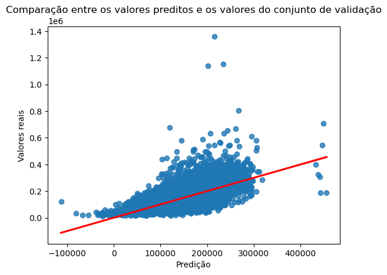

```python
sns.regplot(x=y_pred1, y=y_val, line_kws={'color': 'red'})
plt.xlabel('Predição')
plt.ylabel('Valores reais')
plt.title('Comparação entre os valores preditos e os valores do conjunto de validação')
plt.show()
```

As categorias dropadas pelo `drop_first` foram as seguintes:

```python
set(pd.get_dummies(df, columns=['tipo', 'cambio', 'cor', 'anunciante'])) - set(pd.get_dummies(df, columns=['tipo', 'cambio', 'cor', 'anunciante'], drop_first=True).columns)
```

```
{'anunciante_Acessórios e serviços para autos',
 'cambio_Automatizada',
 'cor_Branco',
 'tipo_Cupê'}
```

A seguir um gráfico que mostra a importância de cada uma das variáveis.

```python
coef = modelo1.named_steps['regressor'].coef_

display(pd.Series(data=coef, index=X.columns))
```

```
num_fotos                       5.959937e+03
ano_de_fabricacao               1.229410e+04
ano_modelo                     -3.988279e+03
hodometro                      -2.217463e+04
num_portas                     -4.082189e+03
blindado                        3.848544e+03
vendedor_PJ                    -6.962999e+03
entrega_delivery               -1.905984e+03
troca                           1.447227e+03
dono_aceita_troca               1.334447e+04
veiculo_único_dono             -4.868548e+03
revisoes_concessionaria         8.940461e+03
ipva_pago                      -2.068955e+03
veiculo_licenciado             -1.483199e+02
garantia_de_fábrica             4.511784e+02
revisoes_dentro_agenda          1.311147e+02
tipo_Hatchback                 -9.661324e+04
tipo_Minivan                   -4.112804e+03
tipo_Perua/SW                  -5.695628e+03
tipo_Picape                    -7.684663e+04
tipo_Sedã                      -1.271116e+05
tipo_Utilitário esportivo      -5.408659e+04
cambio_Automatizada DCT         7.615960e+02
cambio_Automática               4.334609e+03
cambio_Automática Sequencial   -1.148935e+03
cambio_CVT                     -3.273892e+03
cambio_Manual                  -1.436904e+04
cambio_Semi-automática         -5.440473e+02
cor_Cinza                       6.399168e+03
cor_Dourado                     2.245980e+02
cor_Prata                       5.113407e+03
cor_Preto                       6.444179e+03
cor_Verde                       2.392887e+02
cor_Vermelho                    7.275958e-12
anunciante_Concessionária       9.352795e+03
anunciante_Loja                 2.309608e+04
anunciante_Pessoa Física        2.811599e+04
dtype: float64
```

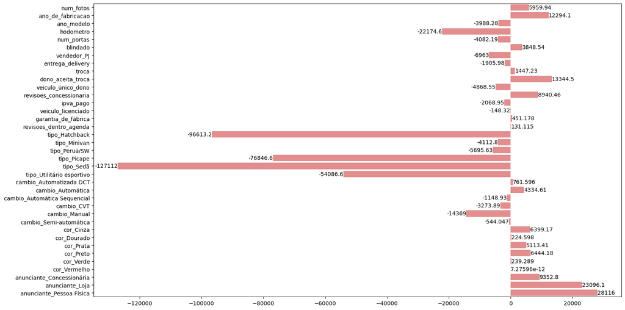

```python
plt.figure(figsize=(16, 8))
ax = sns.barplot(y=X.columns, x=coef, color='lightcoral')
ax.bar_label(ax.containers[0])
ax.figure.tight_layout()
plt.show()
```

Pelos resultados obtidos do modelo, os coeficientes que mais estão impactando na predição do preço estão relacionadas ao tipo de veículo.

### Modelo 2 - RandomForest

O segundo modelo que testaremos é o RandomForest. Esse tipo de modelo tem a grande vantagem de trabalhar bem com variáveis categóricas. A seguir, vamos transformar as variáveis que antes eram dummies em categorias propriamente ditas. Além disso, não será necessário utilizar o `StandardScaler` uma vez que este tipo de algoritmo não sofre com dados fora de escala.

```python
df2 = df.copy()
df2['tipo'] = df2['tipo'].astype('category').cat.codes
df2['cambio'] = df2['cambio'].astype('category').cat.codes
df2['cor'] = df2['cor'].astype('category').cat.codes
df2['anunciante'] = df2['anunciante'].astype('category').cat.codes

df2['marca'] = df2['marca'].astype('category').cat.codes
df2['modelo'] = df2['modelo'].astype('category').cat.codes
df2['versao'] = df2['versao'].astype('category').cat.codes
df2['estado_vendedor'] = df2['estado_vendedor'].astype('category').cat.codes
df2.drop(columns='cidade_vendedor', inplace=True)

X = df2.drop(columns=['preco', 'id'])
y = df2.preco

X_train, X_val, y_train, y_val = train_test_split(X, y, test_size=0.3, random_state=31)

kfold = KFold(n_splits=5, random_state=31, shuffle=True)

modelo2 = RandomForestRegressor(n_estimators=100, random_state=31, n_jobs=-1)

cv_results = cross_validate(modelo2, X_train, y_train, cv=kfold, scoring=['r2', 'neg_root_mean_squared_error'])

r2_scores_cv = cv_results['test_r2']
rmse_scores_cv = cv_results['test_neg_root_mean_squared_error']

print('Cross-validation')
print('Scores do CV (R2):', r2_scores_cv)
print('Média (R2):', r2_scores_cv.mean().round(3))
print('Scores do CV (RMSE):', rmse_scores_cv)
print('Média (RMSE):', rmse_scores_cv.mean().round(2))

print('-'*64)

print('Testes no conjunto de validação')
modelo2.fit(X_train, y_train)
y_pred2 = modelo2.predict(X_val)
r2_scores_val = r2_score(y_val, y_pred2)
rmse_scores_val = -mean_squared_error(y_val, y_pred2, squared=False)
print(f'Score R2: {r2_scores_val:.3f}')
print(f'Score RMSE: {rmse_scores_val:.2f}')
```

```
Cross-validation
Scores do CV (R2): [0.72182901 0.7315763  0.72294216 0.70163202 0.68430552]
Média (R2): 0.712
Scores do CV (RMSE): [-41961.853247   -42596.00533469 -41775.50944505 -45764.74775197
 -46466.77176601]
Média (RMSE): -43712.98
----------------------------------------------------------------
Testes no conjunto de validação
Score R2: 0.727
Score RMSE: -42773.77
```

```python
modelos = pd.concat([modelos,
                     pd.DataFrame([{'modelo': 'modelo2',
                                    'algoritmo': 'RandomForestRegressor',
                                    'r2_score': r2_scores_val.round(3),
                                    'rmse_score': rmse_scores_val.round(2)}]).set_index('modelo')
                                    ])
modelos.style.apply(highlight_max)
# modelos
```

| modelo | algoritmo | r2_score | rmse_score |
| --- | --- | --- | --- |
| modelo1 | LinearRegression | 0.426000 | -62081.360000 |
| modelo2 | RandomForestRegressor | 0.727000 | -42773.770000 |

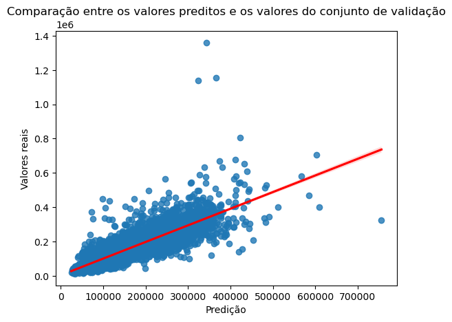

```python
sns.regplot(x=y_pred2, y=y_val, line_kws={'color': 'red'})
plt.xlabel('Predição')
plt.ylabel('Valores reais')
plt.title('Comparação entre os valores preditos e os valores do conjunto de validação')
plt.show()
```

### Feature engineering

Vamos realizar feature engineering para extrair informações presentes na coluna de versão do carro, uma vez que não conseguimos utilizar essa coluna para o modelo de regressão linear.

```python
# Copiando data frame original
df_ft_eng = df.copy()
```

#### Feature `motor`

Vamos utilizar os 3 primeiros dígitos para determinar as cilindradas do motor (ex: 1.0, 1.4, 2.0, etc.). Os carros elétricos não possuem valor de cilindradas, neste caso serão considerados iguais a 0.0.

```python
# os 3 primeiros digitos referem-se as cilindradas do motor
# para os carros elétricos, que não tem essa identificação, o motor foi considerado como igual a 0
df_ft_eng['motor'] = df_ft_eng.versao.str.slice(0, 3).apply(lambda x: float(x) if re.findall('^\d\.\d$', x) else 0.0)
df_ft_eng['motor']
```

```
0        1.6
1        2.0
2        2.4
3        2.0
4        2.0
        ...
29579    2.8
29580    1.0
29581    2.8
29582    1.6
29583    3.0
Name: motor, Length: 29584, dtype: float64
```

#### Feature `combustivel`

A maioria dos carros estava apresentando o tipo de combustível do veículo. As únicas excessões eram alguns carros da Volkswagen (que eram flex), e carros importados (que eram à gasolina).

```python
combustivel = df_ft_eng.versao.apply(lambda car: 'gasolina' if re.findall('GAS', car) else\
                                    ('flex' if re.findall('FLEX|TETRAFUEL', car) else \
                                    ('diesel' if re.findall('DIESEL', car) else \
                                    ('eletrico' if re.findall('ELETRI|ELÉTRI|ELECTRI|RECHARG', car) else \
                                    ('hibrido' if re.findall('HÍBRID|HYBRID|HIBRID', car) else \
                                    ('flex' if re.findall('1\.', car) else 'gasolina')))))) # carros da volkswagen que são flex
df_ft_eng['combustivel'] = combustivel
df_ft_eng['combustivel']
```

```
0            flex
1            flex
2        gasolina
3          diesel
4          diesel
           ...
29579      diesel
29580        flex
29581      diesel
29582        flex
29583    gasolina
Name: combustivel, Length: 29584, dtype: object
```

#### Features `4x4` e `turbo`

Outras features que foram extraídas foram se o veículo é 4x4 e se é turbo:

```python
df_ft_eng['4x4'] = df_ft_eng.versao.str.contains('4X4')
df_ft_eng['turbo'] = df_ft_eng.versao.str.contains('TURBO')

display(df_ft_eng['4x4'])
display(df_ft_eng['turbo'])
```

```
0        False
1        False
2        False
3         True
4         True
         ...
29579     True
29580    False
29581     True
29582    False
29583    False
Name: 4x4, Length: 29584, dtype: bool
```

```
0        False
1        False
2        False
3         True
4         True
         ...
29579     True
29580    False
29581    False
29582    False
29583    False
Name: turbo, Length: 29584, dtype: bool
```

#### Análise das features

Vamos realizar uma análise rápida de como as features se comparam, principalmente com relação ao nosso target.

```python
display(
    df_ft_eng.groupby('motor').preco.mean(),
    df_ft_eng.groupby('combustivel').preco.mean(),
    df_ft_eng.groupby('4x4').preco.mean(),
    df_ft_eng.groupby('turbo').preco.mean()
)
```

```
motor
0.0    246632.879083
0.6    220434.917144
1.0     79865.234668
1.2     49097.244958
1.3    125343.131239
1.4    100025.930860
1.5    108275.142917
1.6    104157.744987
1.7     38398.771642
1.8     91791.807639
1.9     97851.979700
2.0    150055.235390
2.1    156963.098196
2.2    168547.864874
2.3    160659.056177
2.4    113263.301018
2.5    169580.286712
2.7    152259.368243
2.8    231723.688385
2.9    339603.040687
3.0    222598.441463
3.2    198528.821737
3.3    137763.366471
3.5    121376.613455
3.6    164998.677979
3.7     42767.636222
3.8     94533.425051
3.9     71517.534806
4.0    309406.665867
4.1     49924.864046
4.2     99064.225438
4.3     58022.666181
4.4    214123.944767
4.5     57353.165471
4.6     73231.468807
4.7    126822.068318
4.8    108885.328867
4.9     72792.384420
5.0    286501.055520
5.2     62731.123316
5.5    140032.037259
5.7    190230.410261
5.9    125309.699880
6.2    201085.158129
6.7    321207.866029
Name: preco, dtype: float64
```

```
combustivel
diesel      196432.297513
eletrico    248486.768056
flex        100971.230204
gasolina    161622.128140
hibrido     244669.483136
Name: preco, dtype: float64
```

```
4x4
False    124345.131033
True     189395.069191
Name: preco, dtype: float64
```

```
turbo
False    122583.166268
True     166426.753422
Name: preco, dtype: float64
```

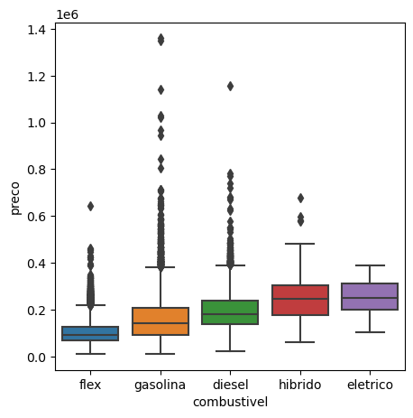

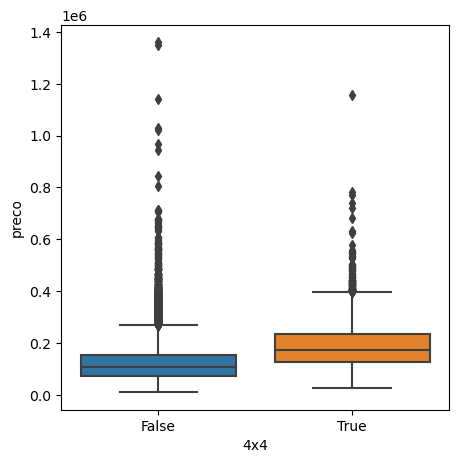

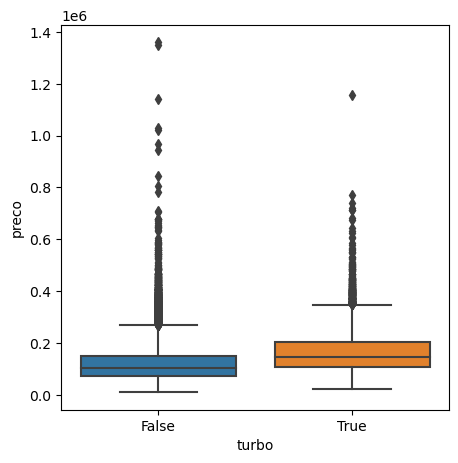

```python
colunas_novas_features = ['combustivel', '4x4', 'turbo']

for feature in colunas_novas_features:
    plt.figure(figsize=(5, 5))
    sns.boxplot(df_ft_eng, x=feature, y='preco')
    plt.show()
```

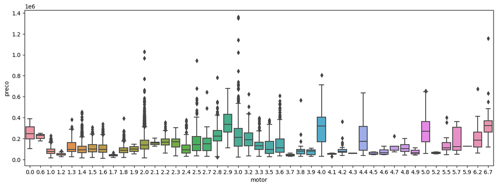

```python
plt.figure(figsize=(15, 5))
sns.boxplot(df_ft_eng, x='motor', y='preco')
plt.show()
```

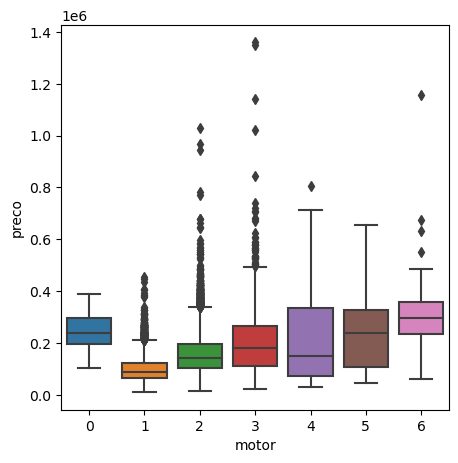

```python
plt.figure(figsize=(5, 5))
sns.boxplot(x=df_ft_eng['motor'].astype(int), y=df_ft_eng['preco'])
plt.show()
```

### Modelo 3 - LinearRegression

Agora faremos os testes novamente utilizando o modelo de Regressão Linear, porém incluindo as features previamente extraídas.

```python
# Criando dummies e removendo a primeira para evitar problemas de colinearidade
df3 = pd.get_dummies(df_ft_eng, columns=['tipo', 'cambio', 'cor', 'anunciante', 'combustivel'], drop_first=True)

X = df3.select_dtypes(np.number).drop(columns=['preco'])
y = df3.preco

X_train, X_val, y_train, y_val = train_test_split(X, y, test_size=0.3, random_state=31)

kfold = KFold(n_splits=5, random_state=31, shuffle=True)

modelo3 = Pipeline([
    ('scaler', StandardScaler()),
    ('regressor', LinearRegression())
])

cv_results = cross_validate(modelo3, X_train, y_train, cv=kfold, scoring=['r2', 'neg_root_mean_squared_error'])

r2_scores_cv = cv_results['test_r2']
rmse_scores_cv = cv_results['test_neg_root_mean_squared_error']

print('Cross-validation')
print('Scores do CV (R2):', r2_scores_cv)
print('Média (R2):', r2_scores_cv.mean().round(3))
print('Scores do CV (RMSE):', rmse_scores_cv)
print('Média (RMSE):', rmse_scores_cv.mean().round(2))

print('-'*64)

print('Testes no conjunto de validação')
modelo3.fit(X_train, y_train)
y_pred3 = modelo3.predict(X_val)
r2_scores_val = r2_score(y_val, y_pred3)
rmse_scores_val = -mean_squared_error(y_val, y_pred3, squared=False)
print(f'Score R2: {r2_scores_val:.3f}')
print(f'Score RMSE: {rmse_scores_val:.2f}')
```

```
Cross-validation
Scores do CV (R2): [0.585127   0.5600588  0.57630511 0.52626461 0.53639156]
Média (R2): 0.557
Scores do CV (RMSE): [-51245.57071097 -54532.54484772 -51661.04033843 -57666.40548422
 -56309.88968191]
Média (RMSE): -54283.09
----------------------------------------------------------------
Testes no conjunto de validação
Score R2: 0.561
Score RMSE: -54261.33
```

```python
modelos = pd.concat([modelos,
                     pd.DataFrame([{'modelo':'modelo3',
                                    'algoritmo': 'LinearRegression',
                                    'r2_score': r2_scores_val.round(3),
                                    'rmse_score': rmse_scores_val.round(2)}]).set_index('modelo')
                                    ])
modelos.style.apply(highlight_max)
```

| modelo | algoritmo | r2_score | rmse_score |
| --- | --- | --- | --- |
| modelo1 | LinearRegression | 0.426000 | -62081.360000 |
| modelo2 | RandomForestRegressor | 0.727000 | -42773.770000 |
| modelo3 | LinearRegression | 0.561000 | -54261.330000 |

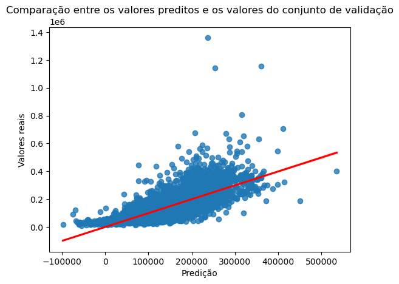

```python
sns.regplot(x=y_pred3, y=y_val, line_kws={'color': 'red'})
plt.xlabel('Predição')
plt.ylabel('Valores reais')
plt.title('Comparação entre os valores preditos e os valores do conjunto de validação')
plt.show()
```

### Modelo 4 - RandomForest

Aplicaremos também o teste com as novas features para o modelo de florestas aleatórias. Espera-se que os resultados não variem muito dos resultados obtidos pelo Modelo 2, uma vez que já estávamos utilizando a coluna de versão dos veículos.

```python
df4 = df_ft_eng.copy()
df4['tipo'] = df4['tipo'].astype('category').cat.codes
df4['cambio'] = df4['cambio'].astype('category').cat.codes
df4['cor'] = df4['cor'].astype('category').cat.codes
df4['anunciante'] = df4['anunciante'].astype('category').cat.codes
df4['combustivel'] = df4['combustivel'].astype('category').cat.codes
df4['marca'] = df4['marca'].astype('category').cat.codes
df4['modelo'] = df4['modelo'].astype('category').cat.codes
df4['versao'] = df4['versao'].astype('category').cat.codes
df4['estado_vendedor'] = df4['estado_vendedor'].astype('category').cat.codes
df4.drop(columns='cidade_vendedor', inplace=True)

X = df4.drop(columns=['preco', 'id'])
y = df4.preco

X_train, X_val, y_train, y_val = train_test_split(X, y, test_size=0.3, random_state=31)

kfold = KFold(n_splits=5, random_state=31, shuffle=True)

modelo4 = RandomForestRegressor(n_estimators=100, random_state=31, n_jobs=-1)

cv_results = cross_validate(modelo4, X_train, y_train, cv=kfold, scoring=['r2', 'neg_root_mean_squared_error'])

r2_scores_cv = cv_results['test_r2']
rmse_scores_cv = cv_results['test_neg_root_mean_squared_error']

print('Cross-validation')
print('Scores do CV (R2):', r2_scores_cv)
print('Média (R2):', r2_scores_cv.mean().round(3))
print('Scores do CV (RMSE):', rmse_scores_cv)
print('Média (RMSE):', rmse_scores_cv.mean().round(2))

print('-'*64)

print('Testes no conjunto de validação')
modelo4.fit(X_train, y_train)
y_pred4 = modelo4.predict(X_val)
r2_scores_val = r2_score(y_val, y_pred4)
rmse_scores_val = -mean_squared_error(y_val, y_pred4, squared=False)
print(f'Score R2: {r2_scores_val:.3f}')
print(f'Score RMSE: {rmse_scores_val:.2f}')
```

```
Cross-validation
Scores do CV (R2): [0.72560512 0.73287973 0.74579278 0.70048952 0.67831817]
Média (R2): 0.717
Scores do CV (RMSE): [-41676.06907268 -42492.45934084 -40015.70499839 -45852.28391507
 -46905.33825826]
Média (RMSE): -43388.37
----------------------------------------------------------------
Testes no conjunto de validação
Score R2: 0.728
Score RMSE: -42705.76
```

```python
modelos = pd.concat([modelos,
                     pd.DataFrame([{'modelo': 'modelo4',
                                    'algoritmo': 'RandomForestRegressor',
                                    'r2_score': r2_scores_val.round(3),
                                    'rmse_score': rmse_scores_val.round(2)}]).set_index('modelo')
                                    ])
modelos.style.apply(highlight_max)
```

| modelo | algoritmo | r2_score | rmse_score |
| --- | --- | --- | --- |
| modelo1 | LinearRegression | 0.426000 | -62081.360000 |
| modelo2 | RandomForestRegressor | 0.727000 | -42773.770000 |
| modelo3 | LinearRegression | 0.561000 | -54261.330000 |
| modelo4 | RandomForestRegressor | 0.728000 | -42705.760000 |

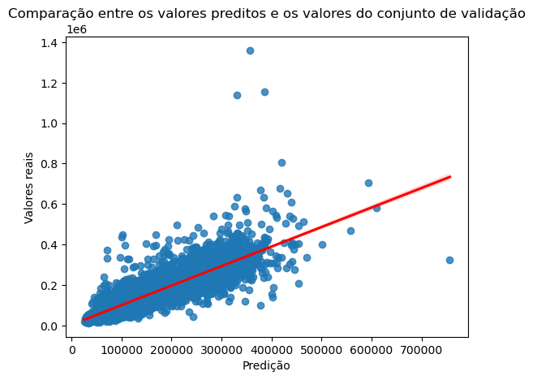

```python
sns.regplot(x=y_pred4, y=y_val, line_kws={'color': 'red'})
plt.xlabel('Predição')
plt.ylabel('Valores reais')
plt.title('Comparação entre os valores preditos e os valores do conjunto de validação')
plt.show()
```

### Modelo 5 - ElasticNet

A seguir, testaremos o modelo de ElasticNet. O algoritmo é uma regressão linear que utiliza alguns parâmetros de penalização a fim de contornar problemas com multicolinearidade e esparsidade.

```python
# Criando dummies e removendo a primeira para evitar problemas de colinearidade
df5 = pd.get_dummies(df_ft_eng, columns=['tipo', 'cambio', 'cor', 'anunciante', 'combustivel',
                                         'marca', 'modelo', 'versao', 'estado_vendedor'], drop_first=True)

X = df5.select_dtypes(np.number).drop(columns=['preco'])
y = df5.preco

X_train, X_val, y_train, y_val = train_test_split(X, y, test_size=0.3, random_state=31)

kfold = KFold(n_splits=5, random_state=31, shuffle=True)

modelo5 = Pipeline([
    ('scaler', StandardScaler()),
    ('regressor', ElasticNet())
])

cv_results = cross_validate(modelo5, X_train, y_train, cv=kfold, scoring=['r2', 'neg_root_mean_squared_error'])

r2_scores_cv = cv_results['test_r2']
rmse_scores_cv = cv_results['test_neg_root_mean_squared_error']

print('Cross-validation')
print('Scores do CV (R2):', r2_scores_cv)
print('Média (R2):', r2_scores_cv.mean().round(3))
print('Scores do CV (RMSE):', rmse_scores_cv)
print('Média (RMSE):', rmse_scores_cv.mean().round(2))

print('-'*64)

print('Testes no conjunto de validação')
modelo5.fit(X_train, y_train)
y_pred5 = modelo5.predict(X_val)
r2_scores_val = r2_score(y_val, y_pred5)
rmse_scores_val = -mean_squared_error(y_val, y_pred5, squared=False)
print(f'Score R2: {r2_scores_val:.3f}')
print(f'Score RMSE: {rmse_scores_val:.2f}')
```

```
Cross-validation
Scores do CV (R2): [0.71164379 0.70476502 0.71534268 0.6894272  0.66880774]
Média (R2): 0.698
Scores do CV (RMSE): [-42723.1635894  -44672.71515852 -42344.56853404 -46691.37631083
 -47593.6597582 ]
Média (RMSE): -44805.1
----------------------------------------------------------------
Testes no conjunto de validação
Score R2: 0.699
Score RMSE: -44939.16
```

```python
modelos = pd.concat([modelos,
                     pd.DataFrame([{'modelo':'modelo5',
                                    'algoritmo': 'ElasticNet',
                                    'r2_score': r2_scores_val.round(3),
                                    'rmse_score': rmse_scores_val.round(2)}]).set_index('modelo')
                                    ])
modelos.style.apply(highlight_max)
```

| modelo | algoritmo | r2_score | rmse_score |
| --- | --- | --- | --- |
| modelo1 | LinearRegression | 0.426000 | -62081.360000 |
| modelo2 | RandomForestRegressor | 0.727000 | -42773.770000 |
| modelo3 | LinearRegression | 0.561000 | -54261.330000 |
| modelo4 | RandomForestRegressor | 0.728000 | -42705.760000 |
| modelo5 | ElasticNet | 0.699000 | -44939.160000 |

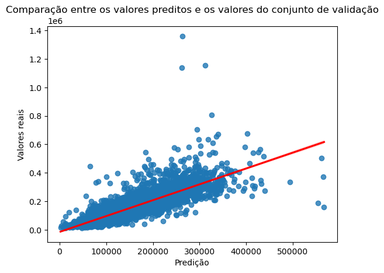

```python
sns.regplot(x=y_pred5, y=y_val, line_kws={'color': 'red'})
plt.xlabel('Predição')
plt.ylabel('Valores reais')
plt.title('Comparação entre os valores preditos e os valores do conjunto de validação')
plt.show()
```

### Feature engineering 2

Outra ideia que pode ser interessante para as previsões é utilizar alguns conceitos de NLP (Natural Language Processing), para trabalharmos com a feature `versao`.

Vamos tokenizar as descrições das versões e criar uma matriz com a presença ou não de cada um dos tokens gerados.

```python
# criando array com os tokens
vectorizer = CountVectorizer()
descriptions_ = vectorizer.fit_transform(df.versao)
descriptions = pd.DataFrame(descriptions_.toarray(), columns=vectorizer.get_feature_names_out())

# realizando contagem dos tokens
desc_counts = descriptions.sum()
unique_versao = df.versao.unique()

desc_counts_df = pd.DataFrame()

for desc in desc_counts.index:
    mask_desc = df.versao.str.contains(fr'\b{desc.upper()}\b')
    desc_row = pd.DataFrame([
        {
            'desc': desc.upper(), # nome do token
            'count': df[mask_desc].versao.shape[0], # quantidade de veiculos vendidos que possuem o token
            'unique_versao': df[mask_desc].versao.unique().shape[0], # quantidade de versões unicas
            'unique_modelo': df[mask_desc].modelo.unique().shape[0], # quantidade de modelos unicos
            'unique_marca': df[mask_desc].marca.unique().shape[0], # quantidade de marcas unicas
            'preco_com': df[mask_desc].preco.mean(), # preco com o token
            'preco_sem': df[~mask_desc].preco.mean() # preco sem o token
        }]
        )
    desc_counts_df = pd.concat([desc_counts_df, desc_row])

desc_counts_df['diferenca'] = desc_counts_df.preco_com - desc_counts_df.preco_sem
```

```python
# Tokens com maior número de ocorrências
desc_counts_df.sort_values('count', ascending=False).head(5)
```

|  | desc | count | unique_versao | unique_modelo | unique_marca | preco_com | preco_sem | diferenca |
| --- | --- | --- | --- | --- | --- | --- | --- | --- |
| 0 | AUTOMÁTICO | 18028 | 843 | 282 | 36 | 138357.102182 | 124703.757722 | 13653.344460 |
| 0 | 4P | 17463 | 1090 | 290 | 34 | 124615.139786 | 145138.542719 | -20523.402932 |
| 0 | 16V | 17349 | 861 | 216 | 33 | 130307.309366 | 136875.925802 | -6568.616436 |
| 0 | FLEX | 15025 | 769 | 142 | 20 | 100114.086890 | 166987.039416 | -66872.952526 |
| 0 | GASOLINA | 7749 | 768 | 312 | 37 | 161242.685367 | 123009.337920 | 38233.347447 |

```python
# Tokens com maior número de versões de carros
desc_counts_df.sort_values('unique_versao', ascending=False).head(5)
```

|  | desc | count | unique_versao | unique_modelo | unique_marca | preco_com | preco_sem | diferenca |
| --- | --- | --- | --- | --- | --- | --- | --- | --- |
| 0 | 4P | 17463 | 1090 | 290 | 34 | 124615.139786 | 145138.542719 | -20523.402932 |
| 0 | 16V | 17349 | 861 | 216 | 33 | 130307.309366 | 136875.925802 | -6568.616436 |
| 0 | AUTOMÁTICO | 18028 | 843 | 282 | 36 | 138357.102182 | 124703.757722 | 13653.344460 |
| 0 | FLEX | 15025 | 769 | 142 | 20 | 100114.086890 | 166987.039416 | -66872.952526 |
| 0 | GASOLINA | 7749 | 768 | 312 | 37 | 161242.685367 | 123009.337920 | 38233.347447 |

```python
# Tokens com maior número de modelos de carros
desc_counts_df.sort_values('unique_modelo', ascending=False).head(5)
```

|  | desc | count | unique_versao | unique_modelo | unique_marca | preco_com | preco_sem | diferenca |
| --- | --- | --- | --- | --- | --- | --- | --- | --- |
| 0 | GASOLINA | 7749 | 768 | 312 | 37 | 161242.685367 | 123009.337920 | 38233.347447 |
| 0 | 4P | 17463 | 1090 | 290 | 34 | 124615.139786 | 145138.542719 | -20523.402932 |
| 0 | AUTOMÁTICO | 18028 | 843 | 282 | 36 | 138357.102182 | 124703.757722 | 13653.344460 |
| 0 | 16V | 17349 | 861 | 216 | 33 | 130307.309366 | 136875.925802 | -6568.616436 |
| 0 | MANUAL | 4896 | 563 | 162 | 30 | 79473.457835 | 143643.730267 | -64170.272432 |

```python
# Tokens com maior número de marcas de carros
desc_counts_df.sort_values('unique_marca', ascending=False).head(5)

# Esses itens tendem a ser mais interessantes visto que são mais universais para os carros
```

|  | desc | count | unique_versao | unique_modelo | unique_marca | preco_com | preco_sem | diferenca |
| --- | --- | --- | --- | --- | --- | --- | --- | --- |
| 0 | GASOLINA | 7749 | 768 | 312 | 37 | 161242.685367 | 123009.337920 | 38233.347447 |
| 0 | AUTOMÁTICO | 18028 | 843 | 282 | 36 | 138357.102182 | 124703.757722 | 13653.344460 |
| 0 | 4P | 17463 | 1090 | 290 | 34 | 124615.139786 | 145138.542719 | -20523.402932 |
| 0 | TURBO | 6998 | 406 | 148 | 34 | 166313.012157 | 122709.643288 | 43603.368869 |
| 0 | 16V | 17349 | 861 | 216 | 33 | 130307.309366 | 136875.925802 | -6568.616436 |

A tokenização da feature `versao` cria uma matriz bastante esparsa, o que pode ser problema para alguns modelos (como o próprio LinearRegression). A seguir vamos refazer alguns testes nos modelos que não sofrem com este tipo de problema.

### Modelo 6 - ElasticNet

Vamos utilizar os tokens criados para tentar novamente uma regressão com o ElasticNet, visto que o seu termo de penalização ajuda a combater problemas com esparsidade.

```python
# Criando dummies e removendo a primeira para evitar problemas de colinearidade
df6 = df.copy()

df6 = pd.concat([df6.drop(columns='id'), descriptions], axis=1)

# Adicionando feature de motor, já que o CountVectorizer desconsiderou para a criação dos tokens
df6['motor'] = df6.versao.str.slice(0, 3).apply(lambda x: float(x) if re.findall('^\d\.\d$', x) else 0.0)

df6 = pd.get_dummies(df6, columns=['tipo', 'cambio', 'cor', 'anunciante', 'marca', 'versao', 'modelo', 'estado_vendedor'], drop_first=True)

X = df6.select_dtypes(np.number).drop(columns=['preco'])
y = df6.preco

X_train, X_val, y_train, y_val = train_test_split(X, y, test_size=0.3, random_state=31)

kfold = KFold(n_splits=5, random_state=31, shuffle=True)

modelo6 = Pipeline([
    ('scaler', StandardScaler()),
    ('regressor', ElasticNet())
])

cv_results = cross_validate(modelo6, X_train, y_train, cv=kfold, scoring=['r2', 'neg_root_mean_squared_error'])

r2_scores_cv = cv_results['test_r2']
rmse_scores_cv = cv_results['test_neg_root_mean_squared_error']

print('Cross-validation')
print('Scores do CV (R2):', r2_scores_cv)
print('Média (R2):', r2_scores_cv.mean().round(3))
print('Scores do CV (RMSE):', rmse_scores_cv)
print('Média (RMSE):', rmse_scores_cv.mean().round(2))

print('-'*64)

print('Testes no conjunto de validação')
modelo6.fit(X_train, y_train)
y_pred6 = modelo6.predict(X_val)
r2_scores_val = r2_score(y_val, y_pred6)
rmse_scores_val = -mean_squared_error(y_val, y_pred6, squared=False)
print(f'Score R2: {r2_scores_val:.3f}')
print(f'Score RMSE: {rmse_scores_val:.2f}')
```

```
Cross-validation
Scores do CV (R2): [0.71953374 0.7094286  0.72153599 0.69369297 0.67677508]
Média (R2): 0.704
Scores do CV (RMSE): [-42134.61790966 -44318.48215723 -41881.38822561 -46369.61061871
 -47017.70507771]
Média (RMSE): -44344.36
----------------------------------------------------------------
Testes no conjunto de validação
Score R2: 0.703
Score RMSE: -44622.41
```

```python
modelos = pd.concat([modelos,
                     pd.DataFrame([{'modelo':'modelo6',
                                    'algoritmo': 'ElasticNet',
                                    'r2_score': r2_scores_val.round(3),
                                    'rmse_score': rmse_scores_val.round(2)}]).set_index('modelo')
                                    ])
modelos.style.apply(highlight_max)
```

| modelo | algoritmo | r2_score | rmse_score |
| --- | --- | --- | --- |
| modelo1 | LinearRegression | 0.426000 | -62081.360000 |
| modelo2 | RandomForestRegressor | 0.727000 | -42773.770000 |
| modelo3 | LinearRegression | 0.561000 | -54261.330000 |
| modelo4 | RandomForestRegressor | 0.728000 | -42705.760000 |
| modelo5 | ElasticNet | 0.699000 | -44939.160000 |
| modelo6 | ElasticNet | 0.703000 | -44622.410000 |

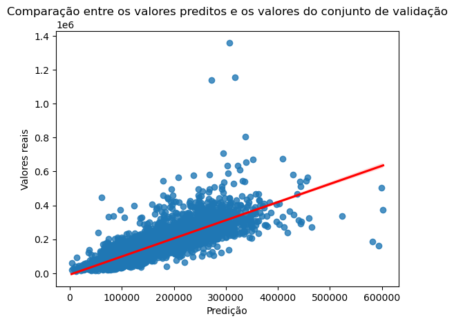

```python
sns.regplot(x=y_pred6, y=y_val, line_kws={'color': 'red'})
plt.xlabel('Predição')
plt.ylabel('Valores reais')
plt.title('Comparação entre os valores preditos e os valores do conjunto de validação')
plt.show()
```

### Modelo 7 - RandomForest

Mais uma vez testaremos o RandomForest, dessa vez com os tokens obtidos anteriormente.

```python
# Criando dummies e removendo a primeira para evitar problemas de colinearidade
df7 = df.copy()

df7 = pd.concat([df7.drop(columns='id'), descriptions], axis=1)

# Adicionando feature de motor, já que o CountVectorizer desconsiderou para a criação dos tokens
df7['motor'] = df7.versao.str.slice(0, 3).apply(lambda x: float(x) if re.findall('^\d\.\d$', x) else 0.0)
df7['tipo'] = df7['tipo'].astype('category').cat.codes
df7['cambio'] = df7['cambio'].astype('category').cat.codes
df7['cor'] = df7['cor'].astype('category').cat.codes
df7['anunciante'] = df7['anunciante'].astype('category').cat.codes
df7['marca'] = df7['marca'].astype('category').cat.codes
df7['modelo'] = df7['modelo'].astype('category').cat.codes
df7['versao'] = df7['versao'].astype('category').cat.codes
df7['estado_vendedor'] = df7['estado_vendedor'].astype('category').cat.codes
df7.drop(columns='cidade_vendedor', inplace=True)

X = df7.select_dtypes(np.number).drop(columns=['preco'])
y = df7.preco

X_train, X_val, y_train, y_val = train_test_split(X, y, test_size=0.3, random_state=31)

kfold = KFold(n_splits=5, random_state=31, shuffle=True)

modelo7 = RandomForestRegressor(n_estimators=100, random_state=31, n_jobs=-1)

cv_results = cross_validate(modelo7, X_train, y_train, cv=kfold, scoring=['r2', 'neg_root_mean_squared_error'])

r2_scores_cv = cv_results['test_r2']
rmse_scores_cv = cv_results['test_neg_root_mean_squared_error']

print('Cross-validation')
print('Scores do CV (R2):', r2_scores_cv)
print('Média (R2):', r2_scores_cv.mean().round(3))
print('Scores do CV (RMSE):', rmse_scores_cv)
print('Média (RMSE):', rmse_scores_cv.mean().round(2))

print('-'*64)

print('Testes no conjunto de validação')
modelo7.fit(X_train, y_train)
y_pred7 = modelo7.predict(X_val)
r2_scores_val = r2_score(y_val, y_pred7)
rmse_scores_val = -mean_squared_error(y_val, y_pred7, squared=False)
print(f'Score R2: {r2_scores_val:.3f}')
print(f'Score RMSE: {rmse_scores_val:.2f}')
```

```
Cross-validation
Scores do CV (R2): [0.72134448 0.73682683 0.75084037 0.70872089 0.68735239]
Média (R2): 0.721
Scores do CV (RMSE): [-41998.38309406 -42177.34665693 -39616.43356153 -45217.82169767
 -46241.99535468]
Média (RMSE): -43050.4
----------------------------------------------------------------
Testes no conjunto de validação
Score R2: 0.730
Score RMSE: -42572.58
```

```python
modelos = pd.concat([modelos,
                     pd.DataFrame([{'modelo': 'modelo7',
                                    'algoritmo': 'RandomForestRegressor',
                                    'r2_score': r2_scores_val.round(3),
                                    'rmse_score': rmse_scores_val.round(2)}]).set_index('modelo')
                                    ])
modelos.style.apply(highlight_max)
```

| modelo | algoritmo | r2_score | rmse_score |
| --- | --- | --- | --- |
| modelo1 | LinearRegression | 0.426000 | -62081.360000 |
| modelo2 | RandomForestRegressor | 0.727000 | -42773.770000 |
| modelo3 | LinearRegression | 0.561000 | -54261.330000 |
| modelo4 | RandomForestRegressor | 0.728000 | -42705.760000 |
| modelo5 | ElasticNet | 0.699000 | -44939.160000 |
| modelo6 | ElasticNet | 0.703000 | -44622.410000 |
| modelo7 | RandomForestRegressor | 0.730000 | -42572.580000 |

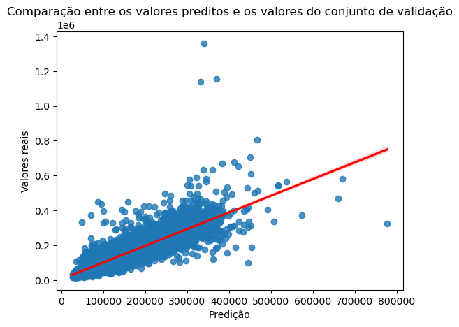

```python
sns.regplot(x=y_pred7, y=y_val, line_kws={'color': 'red'})
plt.xlabel('Predição')
plt.ylabel('Valores reais')
plt.title('Comparação entre os valores preditos e os valores do conjunto de validação')
plt.show()
```

## III) Seleção do modelo e tuning de hiperparâmetro

O melhor modelo encontrado foi o de RandomForest. O modelo pode ser melhorado ainda mais tunando seus hiperparâmetros. Neste caso estaremos usando a função `GridSearchCV` para percorrer todas as combinações de hiperparâmetros repassadas, que foram:

```
'max_depth': [None, 5, 10],
'min_samples_split': [2, 5, 10],
'min_samples_leaf': [1, 2, 4],
```

```python
# Carregando dados e fazendo train test split

df_final = df.copy()

df_final = pd.concat([df_final.drop(columns=['id']), descriptions], axis=1)

# Adicionando feature de motor, já que o CountVectorizer desconsiderou para a criação dos tokens
df_final['motor'] = df_final.versao.str.slice(0, 3).apply(lambda x: float(x) if re.findall('^\d\.\d$', x) else 0.0)
df_final['tipo'] = df_final['tipo'].astype('category').cat.codes
df_final['cambio'] = df_final['cambio'].astype('category').cat.codes
df_final['cor'] = df_final['cor'].astype('category').cat.codes
df_final['anunciante'] = df_final['anunciante'].astype('category').cat.codes
df_final['marca'] = df_final['marca'].astype('category').cat.codes
df_final['modelo'] = df_final['modelo'].astype('category').cat.codes
df_final['versao'] = df_final['versao'].astype('category').cat.codes
df_final['estado_vendedor'] = df_final['estado_vendedor'].astype('category').cat.codes
df_final.drop(columns='cidade_vendedor', inplace=True)

X = df_final.drop(columns=['preco'])
y = df_final.preco

X_train, X_val, y_train, y_val = train_test_split(X, y, test_size=0.3, random_state=31)
```

```python
# Buscando melhores hiperparâmetros

kfold = KFold(n_splits=5, random_state=31, shuffle=True)

random_forest = RandomForestRegressor(n_estimators=100, random_state=31, n_jobs=-1)

modelo_final = GridSearchCV(estimator=random_forest,
                            param_grid={
                                'max_depth': [None, 5, 10],
                                'min_samples_split': [2, 5, 10],
                                'min_samples_leaf': [1, 2, 4],
                            },
                            cv=kfold,
                            scoring=['r2', 'neg_root_mean_squared_error'],
                            refit='r2',
                            n_jobs=-1,
                            )

modelo_final.fit(X_train, y_train)

cv_results = pd.DataFrame(modelo_final.cv_results_)

r2_scores_cv = cv_results[cv_results.rank_test_r2==1]['mean_test_r2']
rmse_scores_cv = cv_results[cv_results.rank_test_r2==1]['mean_test_neg_root_mean_squared_error']

print('Cross-validation')
print('Scores do CV (R2):', cv_results[cv_results.rank_test_r2==1].loc[:, 'split0_test_r2':'split4_test_r2'])
print('Média (R2):', r2_scores_cv.round(3))
print('Scores do CV (RMSE):', cv_results[cv_results.rank_test_r2==1].loc[:, 'split0_test_neg_root_mean_squared_error':'split4_test_neg_root_mean_squared_error'])
print('Média (RMSE):', rmse_scores_cv.round(2))

print('-'*64)

print('Testes no conjunto de validação')
y_pred_final = modelo_final.predict(X_val)
r2_scores_val = r2_score(y_val, y_pred_final)
rmse_scores_val = -mean_squared_error(y_val, y_pred_final, squared=False)
print(f'Score R2: {r2_scores_val:.3f}')
print(f'Score RMSE: {rmse_scores_val:.2f}')
```

```
Cross-validation
Scores do CV (R2):    split0_test_r2  split1_test_r2  split2_test_r2  split3_test_r2  \
8        0.755971        0.736026        0.753076        0.715177

   split4_test_r2
8        0.690658
Média (R2): 8    0.73
Name: mean_test_r2, dtype: float64
Scores do CV (RMSE):    split0_test_neg_root_mean_squared_error  \
8                             -39302.44401

   split1_test_neg_root_mean_squared_error  \
8                            -42241.432616

   split2_test_neg_root_mean_squared_error  \
8                            -39438.318852

   split3_test_neg_root_mean_squared_error  \
8                            -44713.908317

   split4_test_neg_root_mean_squared_error
8                            -45996.904385
Média (RMSE): 8   -42338.6
Name: mean_test_neg_root_mean_squared_error, dtype: float64
----------------------------------------------------------------
Testes no conjunto de validação
Score R2: 0.741
Score RMSE: -41663.04
```

```python
modelos = pd.concat([modelos,
                     pd.DataFrame([{'modelo': 'modelo_final',
                                    'algoritmo': 'RandomForestRegressor',
                                    'r2_score': r2_scores_val.round(3),
                                    'rmse_score': rmse_scores_val.round(2)}]).set_index('modelo')
                                    ])
modelos.style.apply(highlight_max)
# modelos
```

| modelo | algoritmo | r2_score | rmse_score |
| --- | --- | --- | --- |
| modelo1 | LinearRegression | 0.426000 | -62081.360000 |
| modelo2 | RandomForestRegressor | 0.727000 | -42773.770000 |
| modelo3 | LinearRegression | 0.561000 | -54261.330000 |
| modelo4 | RandomForestRegressor | 0.728000 | -42705.760000 |
| modelo5 | ElasticNet | 0.699000 | -44939.160000 |
| modelo6 | ElasticNet | 0.703000 | -44622.410000 |
| modelo7 | RandomForestRegressor | 0.730000 | -42572.580000 |
| modelo_final | RandomForestRegressor | 0.741000 | -41663.040000 |

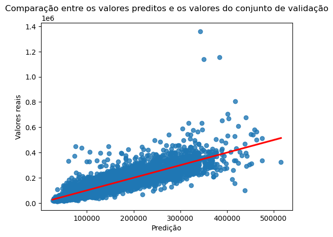

```python
sns.regplot(x=y_pred_final, y=y_val, line_kws={'color': 'red'})
plt.xlabel('Predição')
plt.ylabel('Valores reais')
plt.title('Comparação entre os valores preditos e os valores do conjunto de validação')
plt.show()
```

Apesar da pequena diferença, o tuning de hiperparâmetros gerou um resultado melhor que os anteriores.

Os melhores hiperparâmetros foram:

```python
best_params = modelo_final.best_params_
best_params
```

```
{'max_depth': None, 'min_samples_leaf': 4, 'min_samples_split': 10}
```

Vamos verificar qual a importância das features do modelo.

```python
# rfr = RandomForestRegressor(**{'max_depth': None, 'min_samples_leaf': 4, 'min_samples_split': 10})
rfr = RandomForestRegressor(**best_params)

rfr.fit(X_train, y_train)
```

```
RandomForestRegressor(min_samples_leaf=4, min_samples_split=10)
```

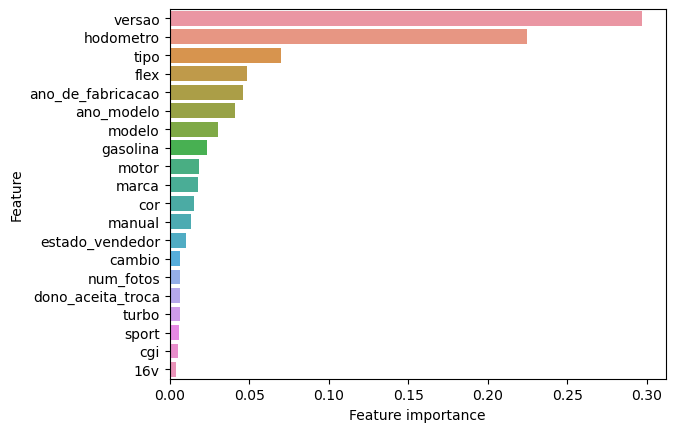

```python
feature_importance = pd.Series(data=rfr.feature_importances_, index=rfr.feature_names_in_).sort_values(ascending=False)

top20_features = feature_importance.head(20)

sns.barplot(x=top20_features, y=top20_features.index)
plt.xlabel('Feature importance')
plt.ylabel('Feature')
plt.show()
```

```python
# Treinando o modelo com todos os dados do conjunto de treino
rfr.fit(X, y)
vectorizer = CountVectorizer().fit(df.versao)
```

## IV) Exportação do modelo e dos resultados

Nosso modelo final que irá para a produção será um RandomForestRegressor. Os resultados a serem exportados encontram-se a seguir:

```python
# Ler dados de teste
df_test_raw = pd.read_csv('./datasets/cars_test.csv', sep='\t', encoding='utf_16')

df_test = df_test_raw.copy()

# Utilizando vectorizer previamente definido para obter a matriz de tokens
descriptions_test = vectorizer.transform(df_test.versao.astype(str))
descriptions_test = pd.DataFrame(descriptions_test.toarray(), columns=vectorizer.get_feature_names_out())

df_test = pd.concat([df_test.drop(columns='id'), descriptions_test], axis=1)

df_test['motor'] = df_test.versao.str.slice(0, 3).apply(lambda x: float(x) if re.findall('^\d\.\d$', x) else 0.0)

# Transformar para inteiro
df_test['ano_modelo'] = df_test.ano_modelo.astype(int)
df_test['num_fotos'] = df_test.num_fotos.fillna(0).astype(int)

# Transformar em booleanos
df_test['dono_aceita_troca'] = df_test.dono_aceita_troca.notnull().astype(int)
df_test['veiculo_único_dono'] = df_test.veiculo_único_dono.notnull().astype(int)
df_test['revisoes_concessionaria'] = df_test.revisoes_concessionaria.notnull().astype(int)
df_test['ipva_pago'] = df_test.ipva_pago.notnull().astype(int)
df_test['veiculo_licenciado'] = df_test.veiculo_licenciado.notnull().astype(int)
df_test['garantia_de_fábrica'] = df_test.garantia_de_fábrica.notnull().astype(int)
df_test['revisoes_dentro_agenda'] = df_test.revisoes_dentro_agenda.notnull().astype(int)
df_test['entrega_delivery'] = df_test.entrega_delivery.astype(int)
df_test['troca'] = df_test.troca.astype(int)
df_test['blindado'] = df_test.blindado.map({'N': 0, 'S': 1})

# Colunas descartadas
df_test.drop(columns=['veiculo_alienado'], inplace=True)
df_test.drop(columns=['elegivel_revisao'], inplace=True)

# Remapeando tipo_vendedor e alterando o nome da variável
df_test['tipo_vendedor'] = df_test.tipo_vendedor.map({'PJ': 1, 'PF': 0})
df_test.rename(columns={'tipo_vendedor':'vendedor_PJ'}, inplace=True)

df_test['tipo'] = df_test['tipo'].astype('category').cat.codes
df_test['cambio'] = df_test['cambio'].astype('category').cat.codes
df_test['cor'] = df_test['cor'].astype('category').cat.codes
df_test['anunciante'] = df_test['anunciante'].astype('category').cat.codes

df_test['marca'] = df_test['marca'].astype('category').cat.codes
df_test['modelo'] = df_test['modelo'].astype('category').cat.codes
df_test['versao'] = df_test['versao'].astype('category').cat.codes
df_test['estado_vendedor'] = df_test['estado_vendedor'].astype('category').cat.codes
df_test.drop(columns='cidade_vendedor', inplace=True)

X_test = df_test
```

```python
# obtendo os resultados para o conjunto de teste
y_test_pred = rfr.predict(X_test)
```

```python
# data frame do conjunto de teste mais as predições obtidas
df_pred = pd.concat([df_test_raw, pd.Series(y_test_pred, name='preco')], axis=1)
```

```python
df_pred.head()
```

|  | id | num_fotos | marca | modelo | versao | ano_de_fabricacao | ano_modelo | hodometro | cambio | num_portas | tipo | blindado | cor | tipo_vendedor | cidade_vendedor | estado_vendedor | anunciante | entrega_delivery | troca | elegivel_revisao | dono_aceita_troca | veiculo_único_dono | revisoes_concessionaria | ipva_pago | veiculo_licenciado | garantia_de_fábrica | revisoes_dentro_agenda | veiculo_alienado | preco |
| --- | --- | --- | --- | --- | --- | --- | --- | --- | --- | --- | --- | --- | --- | --- | --- | --- | --- | --- | --- | --- | --- | --- | --- | --- | --- | --- | --- | --- | --- |
| 0 | 13518783164498355150900635905895481162 | 8.0 | NISSAN | VERSA | 1.6 16V FLEXSTART V-DRIVE MANUAL | 2021 | 2021.0 | 20258.0 | Manual | 4 | Hatchback | N | Branco | PF | Rio de Janeiro | São Paulo (SP) | Pessoa Física | False | False | False | Aceita troca | NaN | NaN | IPVA pago | Licenciado | Garantia de fábrica | NaN | NaN | 107805.653017 |
| 1 | 299896161723793383246777788797566040330 | 18.0 | FIAT | STRADA | 1.4 MPI WORKING CS 8V FLEX 2P MANUAL | 2021 | 2021.0 | 53045.0 | Manual | 2 | Picape | N | Branco | PJ | Palmas | Amazonas (AM) | Loja | False | False | False | Aceita troca | Único dono | NaN | IPVA pago | Licenciado | NaN | NaN | NaN | 118655.633340 |
| 2 | 316180649972302128246133616457018378621 | 8.0 | AUDI | Q5 | 2.0 TFSI GASOLINA BLACK S TRONIC | 2018 | 2019.0 | 32486.0 | Automática | 4 | Utilitário esportivo | N | Branco | PF | Goiânia | Goiás (GO) | Pessoa Física | False | False | False | Aceita troca | NaN | NaN | IPVA pago | NaN | NaN | NaN | NaN | 246612.708120 |
| 3 | 222527157104148385909188217274642813298 | 16.0 | CHEVROLET | CRUZE | 1.4 TURBO LT 16V FLEX 4P AUTOMÁTICO | 2019 | 2020.0 | 24937.0 | Automática | 4 | Sedã | N | Cinza | PJ | Presidente Prudente | São Paulo (SP) | Loja | False | False | False | Aceita troca | Único dono | NaN | IPVA pago | Licenciado | NaN | NaN | NaN | 126877.358218 |
| 4 | 160460343059850745858546502614838368036 | 8.0 | FORD | ECOSPORT | 1.5 TI-VCT FLEX SE AUTOMÁTICO | 2019 | 2019.0 | 62074.0 | Automática | 4 | Sedã | N | Branco | PJ | Limeira | São Paulo (SP) | Loja | False | False | False | Aceita troca | NaN | NaN | IPVA pago | Licenciado | NaN | NaN | NaN | 140117.314263 |

```python
# gerando o arquivo .csv conforme solicitado
df_pred_resumo = df_pred[['id', 'preco']]
df_pred_resumo.to_csv('./datasets/predicted.csv', sep=';', index=False)
```

```python
df_pred_resumo
```

|  | id | preco |
| --- | --- | --- |
| 0 | 13518783164498355150900635905895481162 | 107805.653017 |
| 1 | 299896161723793383246777788797566040330 | 118655.633340 |
| 2 | 316180649972302128246133616457018378621 | 246612.708120 |
| 3 | 222527157104148385909188217274642813298 | 126877.358218 |
| 4 | 160460343059850745858546502614838368036 | 140117.314263 |
| ... | ... | ... |
| 9857 | 270530958308663978454359593206239054667 | 118274.837589 |
| 9858 | 35444226755331218706378362485070904721 | 218587.226972 |
| 9859 | 151927592621490440610866139377092833936 | 141623.846923 |
| 9860 | 118047837484645467440786911677256539035 | 130614.333918 |
| 9861 | 332784980027104367393384305973418103109 | 217246.692543 |

9862 rows × 2 columns

```python
# Salvando o modelo em arquivo
dump(rfr, './model/rfr.joblib')
```

```
['./model/rfr.joblib']
```

```python
# Para carregar o modelo usamos:
modelo_carregado = load('./model/rfr.joblib')
modelo_carregado.predict(X_test)
```

```
array([107805.65301691, 118655.63334018, 246612.70812004, ...,
       141623.84692319, 130614.33391832, 217246.69254347])
```

## V) Conclusões

Os modelos baseados em árvores de decisão apresentaram uma performance superior aos modelos baseados em regressão linear.

Uma dificuldade que estes modelos poderão encontrar são com o tratamento de outliers, visto que o RandomForest não é recomendado para extrapolação de valores.

Foram utilizadas algumas técnicas de NLP (Natural Language Processing) sendo gerados vários tokens para as descrições dos carros, e espera-se que, caso novos carros sejam adicionados, o modelo consiga absorver os textos das descrições dos veículos e possa interpretar e atribuir um valor a ele com base em suas características.

Para os veículos que já estavam na base de dados, a feature `versao` já traz boas informações para predição dos preços, conforme apontado pelo gráfico de importância das features, contudo para veículos não vistos nesse conjunto, o modelo teria dificuldade em entender o carro em questão, caso ele se baseie apenas nessa coluna.

Outra feature importante para a predição do preço foi a quilometragem do veículo, o que faz bastante sentido quando se pensa no problema real. Veículos com maior rodagem tendem a apresentar desgastes e na hora das vendas, o hodômetro certamente será um fato de desvalorização na precificação.

Algumas outras ideias para realizarmos predições mais assertivas seriam:

- Consultar valores da tabela FIPE: é bastante comum a utilização dessa tabela para negociação de veículos, e é inclusive usada como critério para valor venal no cálculo do IPVA.
- Confrontar as vendas com outras características demográficas das cidades/estados: utilizou-se o PIB e a população para indicar correlação nas vendas, porém percebeu-se apenas correlação na quantidade e não nos preços. Número de veículos da cidade, por exemplo, poderia ser uma informação relevante para a análise dos dados.
- Fazer uma limpeza no dataset mais profunda, e principalmente entender como os dados foram obtidos: durante a exploração de dados percebeu-se que algumas colunas não condiziam com as demais, porém como não sabíamos a origem dos dados é difícil de se afirmar quais dados realmente estavam incorretos. Exemplo, um veículo poderia apresentar em sua descrição 2P e no seu número de portas apresentar 4, mas qual dessas informações estaria realmente correta?
- Aplicar outros tipos de modelos: neste trabalho concentramos em apenas métodos de regressão linear e o RandomForest. Existem vários outros métodos como SVMs, Gradient Boosting, Redes Neurais, etc. que poderiam apresentar resultados diferentes dos obtidos aqui.
- Reduzir dimensionalidade das features extraídas por NLP: a matriz gerada é grande e apresenta colunas que não farão diferença na predição dos preços dos veículos.